# 52414 - lab 1 Solutions

Halit Cohen 318356854 and Yoray Mauda 315874404

15/5/2022

**Solution:**

### Question 1

In this section, we will load the data frame, and will compute basic processing. Plus, we will list a table the top five dates as requested.

###### A

First, we will load the data, straight from GitHub:

```r
df <- read.csv("https://raw.githubusercontent.com/DataScienceHU/r52414_2021_22_lab1-Mauda_Yoray_and_Cohen_Halit/main/owid-covid-data.csv")
```

Secondly, we will modify the data & change the date column to an actual date class, in order to use it. Lets print & check:

```r
df$date <- as.Date(df$date,origin = "%Y-%m-%d")
class(df$date)
```

```
## [1] "Date"
```

###### B

In this sub question, we will compute in a table the top five dates in terms of number of new cases for High income cases. Later, we will do the same in “New Deaths” & “New Vaccinations”.

```r
High_income_new_cases <- filter(df,location == "High income")%>%
  arrange(desc(new_cases))
top_n(High_income_new_cases[c("date","new_cases")],5)
```

```
##         date new_cases
## 1 2022-01-19   2830641
## 2 2022-01-18   2737975
## 3 2022-01-10   2589466
## 4 2022-01-21   2559046
## 5 2022-01-26   2532235
```

```r
High_income_new_deaths <- filter(df,location == "High income")%>%
  arrange(desc(new_deaths))
top_n(High_income_new_cases[c("date","new_deaths")],5)
```

```
##         date new_deaths
## 1 2021-01-08       9962
## 2 2021-01-12      10178
## 3 2021-01-20      11027
## 4 2021-01-27      10057
## 5 2021-01-26      10283
```

```r
High_income_new_vaccinations <- filter(df,location == "High income")%>%
  arrange(desc(new_vaccinations))
top_n(High_income_new_cases[c("date","new_vaccinations")],5)
```

```
##         date new_vaccinations
## 1 2021-12-17          9758491
## 2 2021-08-04         12018836
## 3 2021-06-11          9457680
## 4 2021-06-10          9561360
## 5 2021-06-09          9527959
```

### Question 2

In this Question, we will compute a function that plots high and low income in one graph, as a function of date. We were requested to remove NA data, and since we use the library “ggplot2”, it does it by itself.

###### A

```r
function_question2 <- function(data_frame, col_name)
{
  filtered_covid_data_high <- data_frame %>% filter(location == "High income")
  filtered_covid_data_low <- data_frame %>% filter(location == "Low income")
  ggplot(filtered_covid_data_high, aes(date, {{col_name}})) + geom_point() +
    geom_point(data = filtered_covid_data_low, colour = "red")
}
```

###### B

In this sub-question, we create four more plots based on demand

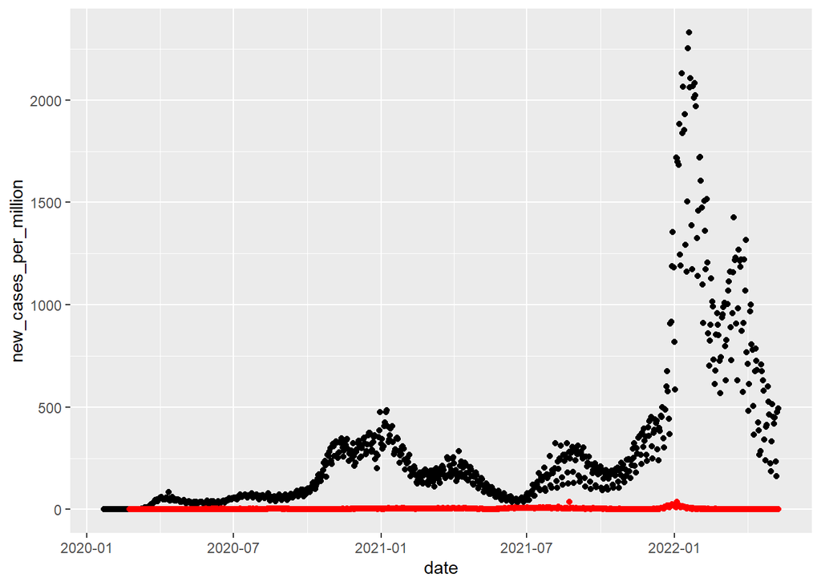

```r
plot_1 <- function_question2(df,new_cases_per_million)
plot_1
```

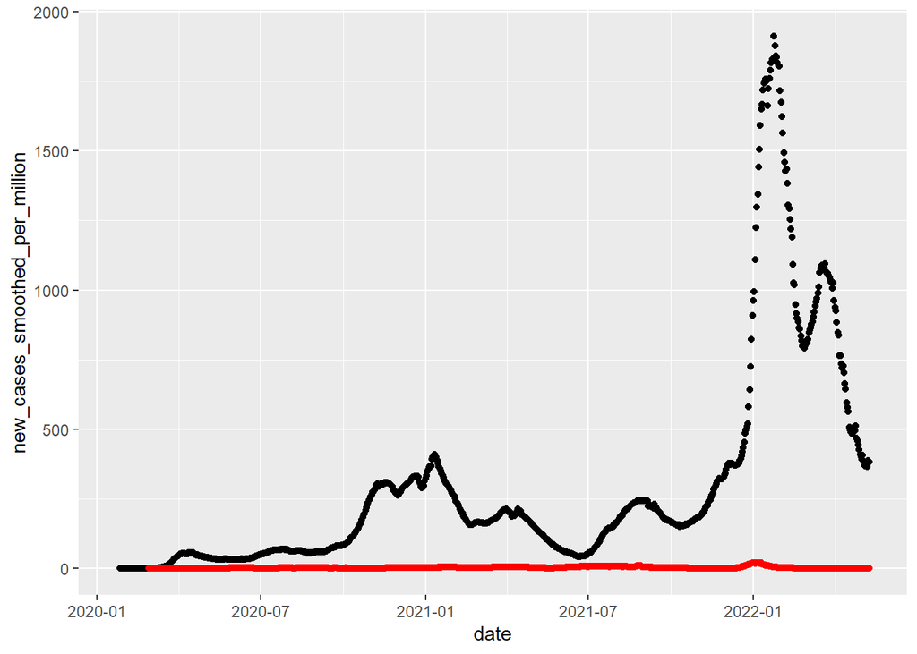

```r
plot_2 <- function_question2(df,new_cases_smoothed_per_million)
plot_2
```

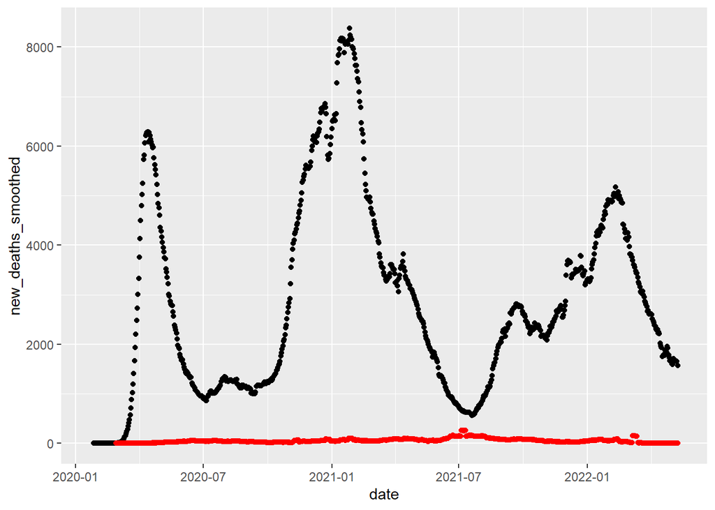

```r
plot_3 <- function_question2(df,new_deaths_smoothed)
plot_3
```

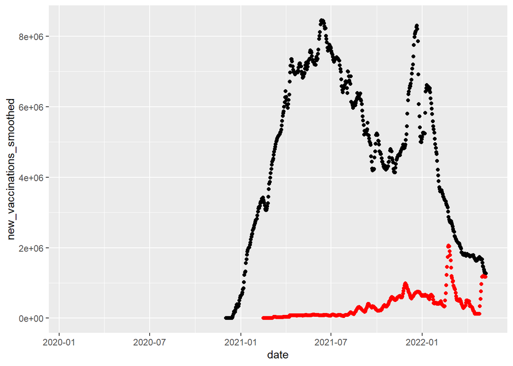

```r
plot_4 <- function_question2(df,new_vaccinations_smoothed)
plot_4
```

##### Analysis & Results

In the plots, the red color is the low income places. We can see that we have lower results in all the graphs in all the parameters. We think that because these are lower income countries, they do not have sufficient information to give, and that’s why we have so little results for them.

### Question 3

In this Question, we will store and compute a new data frame, with different current values for different parameters, whether it is total cases, deaths, vaccinations, or boosters.

##### A

First, we will filter the desired information.

```r
df_c<-df%>%fill(c("continent","total_cases_per_million","total_vaccinations_per_hundred","people_fully_vaccinated_per_hundred","total_boosters_per_hundred","excess_mortality_cumulative_per_million","total_deaths_per_million","date"), .direction = 'down')
current <-df_c[c("location","continent","total_cases_per_million","total_vaccinations_per_hundred","people_fully_vaccinated_per_hundred","total_boosters_per_hundred","excess_mortality_cumulative_per_million","total_deaths_per_million","date")] %>%group_by(location)%>%slice(which.max(date))
```

###### B

Now, we will create a plot and compute the skewness and kurtosis.

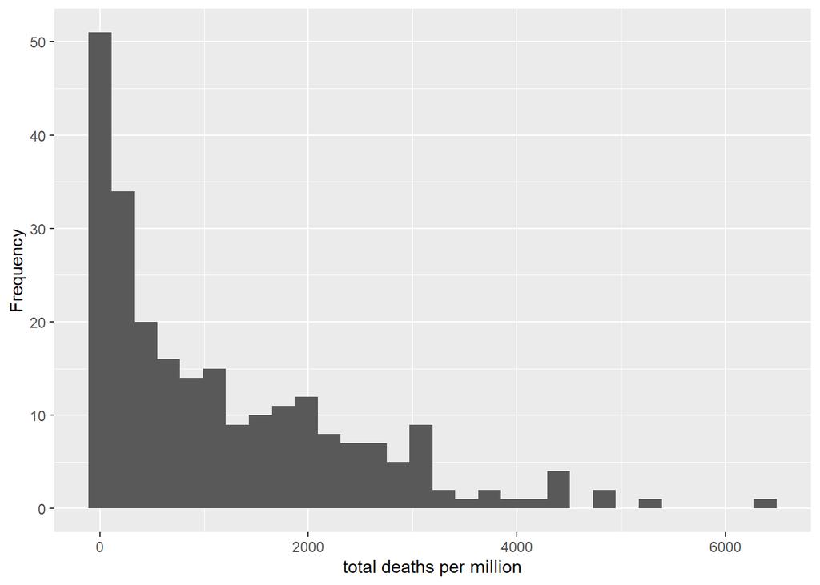

```r
ggplot(current, aes(x=total_deaths_per_million))+geom_histogram(bins = 30)+labs(x="total deaths per million", y="Frequency")
```

```r
tdpm <- current$total_deaths_per_million
tdpm[tdpm == ""]<-NA
tdpm_1<-na.omit(tdpm)
skewness<-skewness(tdpm_1)
kurtosis<-kurtosis(tdpm_1)
skewness
```

```
## [1] 1.283092
```

```r
kurtosis
```

```
## [1] 1.459567
```

###### C

In this section we will create a linear regression module, and will show the results in a plot.

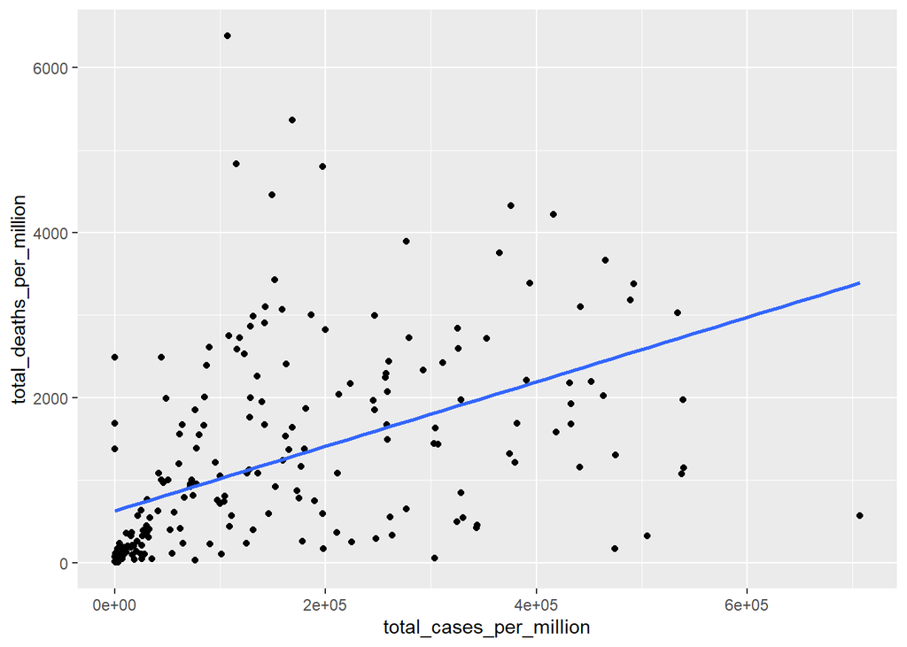

```r
ggplot(current,aes( x=total_cases_per_million, y=total_deaths_per_million))+geom_point()+
  geom_smooth(method=lm,se=FALSE)
```

```r
lm(current$total_deaths_per_million~current$total_cases_per_million)
```

```
##
## Call:
## lm(formula = current$total_deaths_per_million ~ current$total_cases_per_million)
##
## Coefficients:
##                     (Intercept)  current$total_cases_per_million
##                       6.297e+02                        3.911e-03
```

As we can see, there a certain correlation with the linear regression line.

### Question 4

In this section we will make a box plot of six different continents: Africa, Asia, Europe, North America, Oceania and South America. The plot will present the total number of vaccinations in all six different continents.

###### A

When looking at a first glance, we can see the continents info isn’t fully typed correctly, thus some of the details are misplaced. We will organize it first.

```r
current_q4 <- current[c("continent","total_vaccinations_per_hundred")]
current_q4[current_q4 ==""]<- NA
current_q4 <-na.omit(current_q4)
```

after reorganizing, we will create the plot:

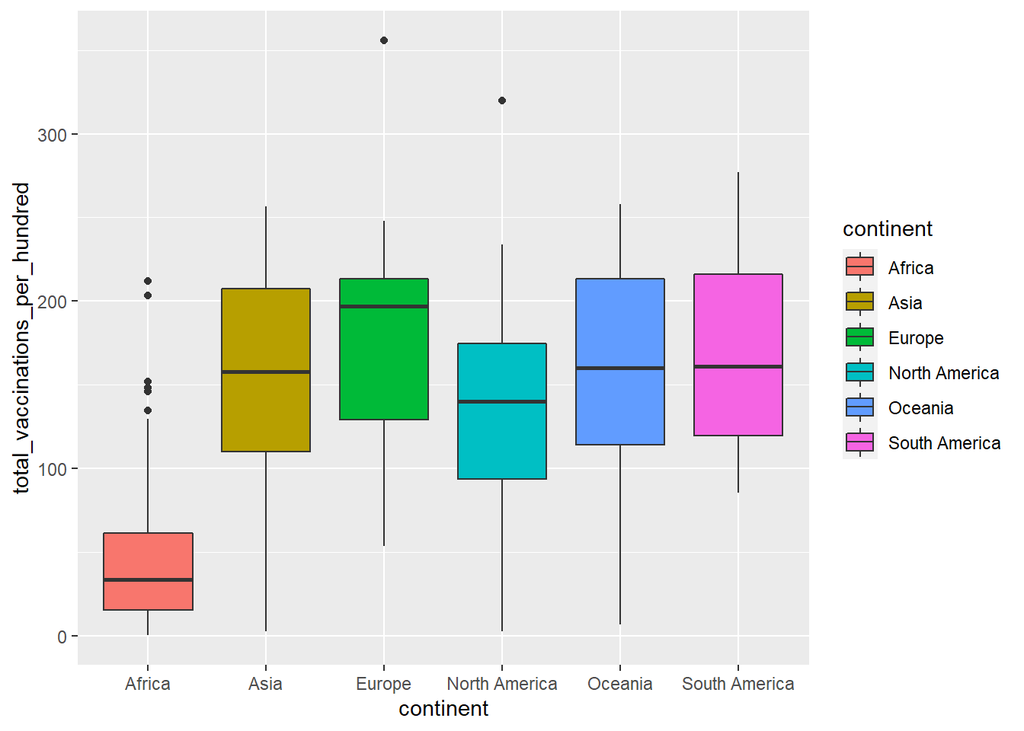

```r
ggplot(current_q4, aes(x = continent, y = total_vaccinations_per_hundred,fill=continent)) + geom_boxplot()
```

###### B

Here we will define a new column called “booster ration”, that will show the fraction of individuals that got to shots, by dates.

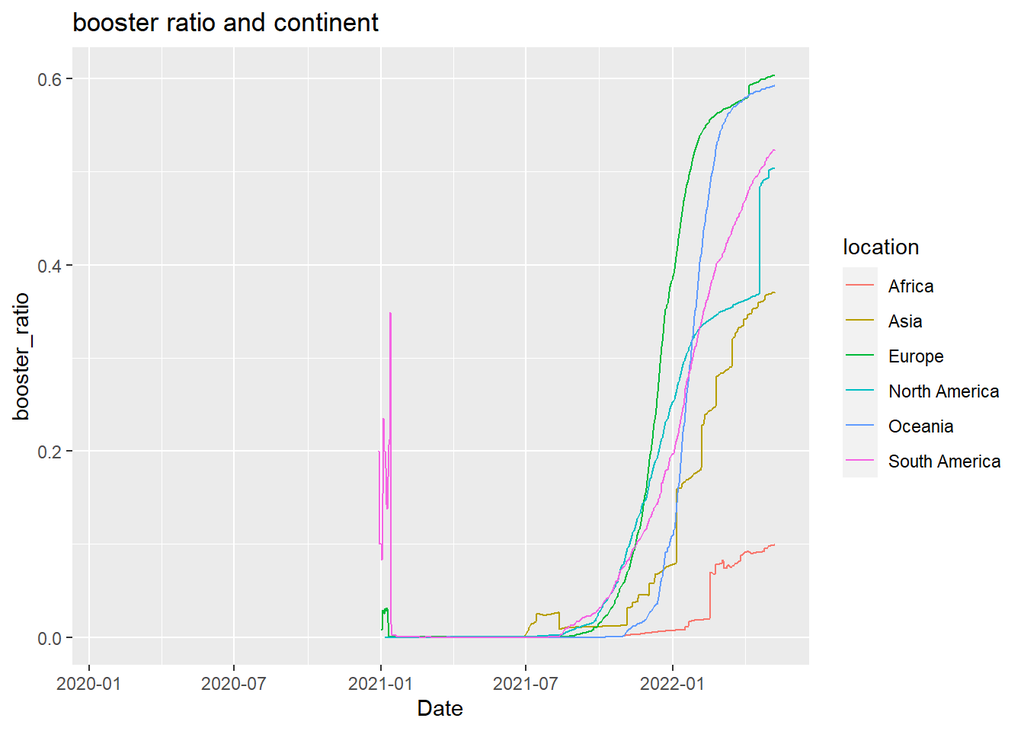

```r
#Add a new field and group the data into groups
df_q4 <- df%>%group_by(location)%>%mutate(booster_ratio=total_boosters/people_fully_vaccinated)
df_q4<-subset(df_q4,location %in% c('Africa', 'Asia', 'Europe', 'North America', 'Oceania', 'South America'))
ggplot(df_q4,aes(x=date,y=booster_ratio,color=location))+geom_line()+labs(title = "booster ratio and continent",x="Date", y="booster_ratio")
```

##### Analysis & Results

As we can see, the booster ration keep on rising as the days go.

### Question 5

###### A

In this section we will make a box plot by the with new cases per million for each month, plotted by year, and the plot will represent the empirical distribution to the values.

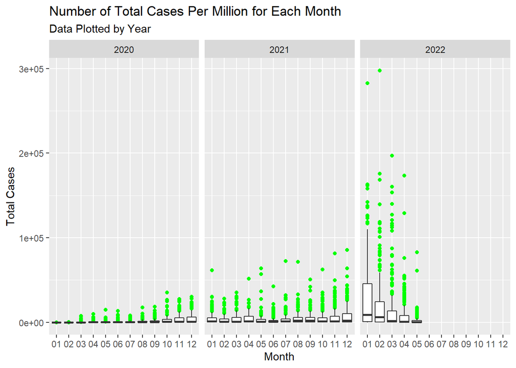

```r
reduced_df = subset(df, continent != '')
reduced_df$year <- strftime(reduced_df$date, "%Y")
reduced_df$month <- strftime(reduced_df$date, "%m")
agg_reduced_df_a <- aggregate(new_cases_per_million ~ month + year + location, reduced_df, FUN = sum)
agg_reduced_df_a$date <- with(agg_reduced_df_a, paste(year, month,sep="-"))
new_cases_per_million_boxplot <- agg_reduced_df_a %>% ggplot(aes(x= month, y= new_cases_per_million)) +
  geom_boxplot(outlier.colour = "green") + facet_wrap(~year, ncol=3) +
  labs(title = "Number of Total Cases Per Million for Each Month",
       subtitle = "Data Plotted by Year", y= "Total Cases", x= "Month")
new_cases_per_million_boxplot
```

###### B

Now for new deaths:

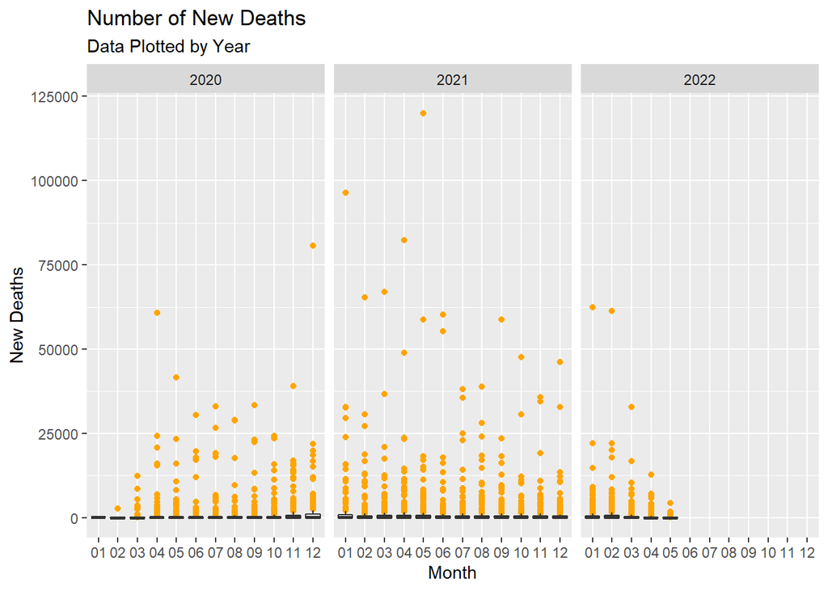

```r
agg_reduced_df_death <- aggregate(new_deaths ~ month + year + location, reduced_df, FUN = sum)
agg_reduced_df_death$date <- with(agg_reduced_df_death, paste(year, month,sep="-"))
new_deaths_boxplot <- agg_reduced_df_death %>% ggplot(aes(x= month, y= new_deaths)) +
  geom_boxplot(outlier.colour = "orange") + facet_wrap(~year, ncol = 3) +
  labs(title = "Number of New Deaths", subtitle = "Data Plotted by Year",
       y= "New Deaths", x= "Month")
new_deaths_boxplot
```

And for new vaccination:

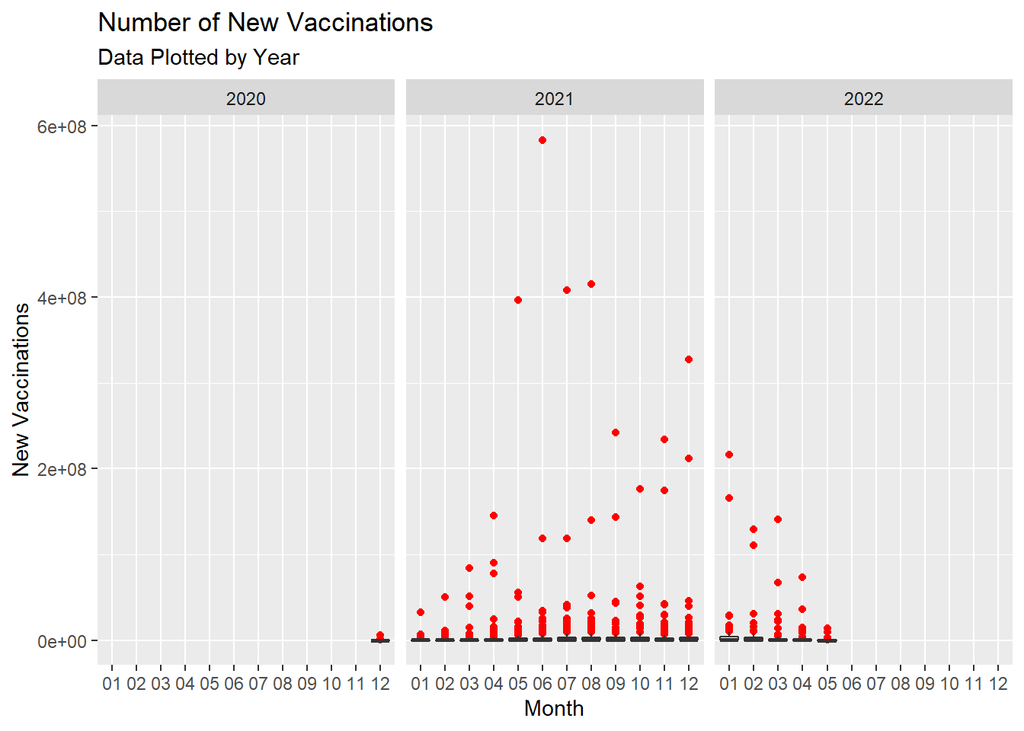

```r
agg_reduced_df_vaccinations <- aggregate(new_vaccinations ~ month + year + location, reduced_df, FUN = sum)
agg_reduced_df_vaccinations$date <- with(agg_reduced_df_vaccinations, paste(year, month,sep="-"))
new_vaccinations_boxplot <- agg_reduced_df_vaccinations %>% ggplot(aes(x= month, y= new_vaccinations)) +
  geom_boxplot(outlier.colour = "red") + facet_wrap(~year, ncol = 3) +
  labs(title = "Number of New Vaccinations", subtitle = "Data Plotted by Year",
       y= "New Vaccinations", x= "Month")
new_vaccinations_boxplot
```

##### Analysis & Results

For total cases: we can see at the beginning that the lock down was more strict and thus the number of total cases was a bit lower during 2020 and 2021. In 2022, the numbers are higher. For new deaths: we can see that the new number of deaths is higher in 2021, and we can clearly see the numbers go down as new vaccination go up. For new vaccinations: we can see a massive rise in vaccinations in middle 2021, and then a slow decline further.

### Question 6

In This question we will create a column that represents the R0 reproduction factor.

```r
df_for6 <- df %>% group_by(location) %>% mutate(R_cases = new_cases_smoothed /
                                                  lag(new_cases_smoothed, n = 7))
df_for6$R_cases[is.infinite(df_for6$R_cases)] <- NA
```

Now, we’ll create a plot for UK, Israel & USA, as a function of time. Then, we will list in a table the number of days the disease was spreading. We will (by order): subset the desired places, plot the cases per place, and we will create a list for days the R0 was above 1:

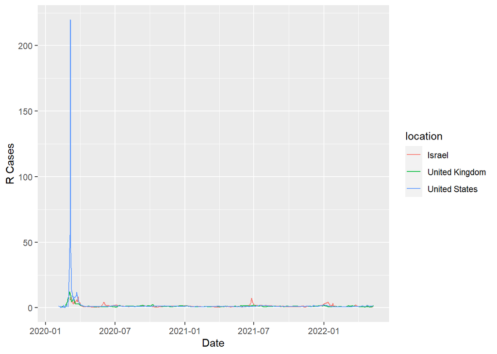

```r
subset_places <- subset(df_for6, location %in% c("Israel", "United Kingdom", "United States"))
subset_places_plot <- ggplot(subset_places, aes(x= date, y= R_cases, color= location)) + labs(x= "Date", y= "R Cases") + geom_line()
subset_places_plot
```

Now we will compute the list for when these countries had R cases above 1:

```r
places <- c("UK", "US", "IL")
R_cases_1 <- c(sum(subset(subset_places, location == "United States")$R_cases > 1, na.rm = TRUE), sum(subset(subset_places, location == "United Kingdom")$R_cases > 1, na.rm = TRUE), sum(subset(subset_places, location == "Israel")$R_cases > 1, na.rm = TRUE))
R_list <- data.frame(places, R_cases_1)
R_list
```

[output not shown]

### Question 7

In this section we will display several data on a world map, using the library rworldmap.

```r
mapdata_deaths<-df[c("location","total_deaths_per_million")]%>%group_by(location)%>%slice(which.max(total_deaths_per_million))
mapdata_vaccinations<-df[c("location","total_vaccinations_per_hundred")]%>%group_by(location)%>%slice(which.max(total_vaccinations_per_hundred))
mapdata_mortality<-df[c("location","excess_mortality_cumulative_per_million")]%>%group_by(location)%>%slice(which.max(excess_mortality_cumulative_per_million))
#Creating the maps
map_world_deaths<-joinCountryData2Map(mapdata_deaths,joinCode = "NAME",nameJoinColumn = "location")
```

```
## 203 codes from your data successfully matched countries in the map
## 18 codes from your data failed to match with a country code in the map
## 40 codes from the map weren't represented in your data
```

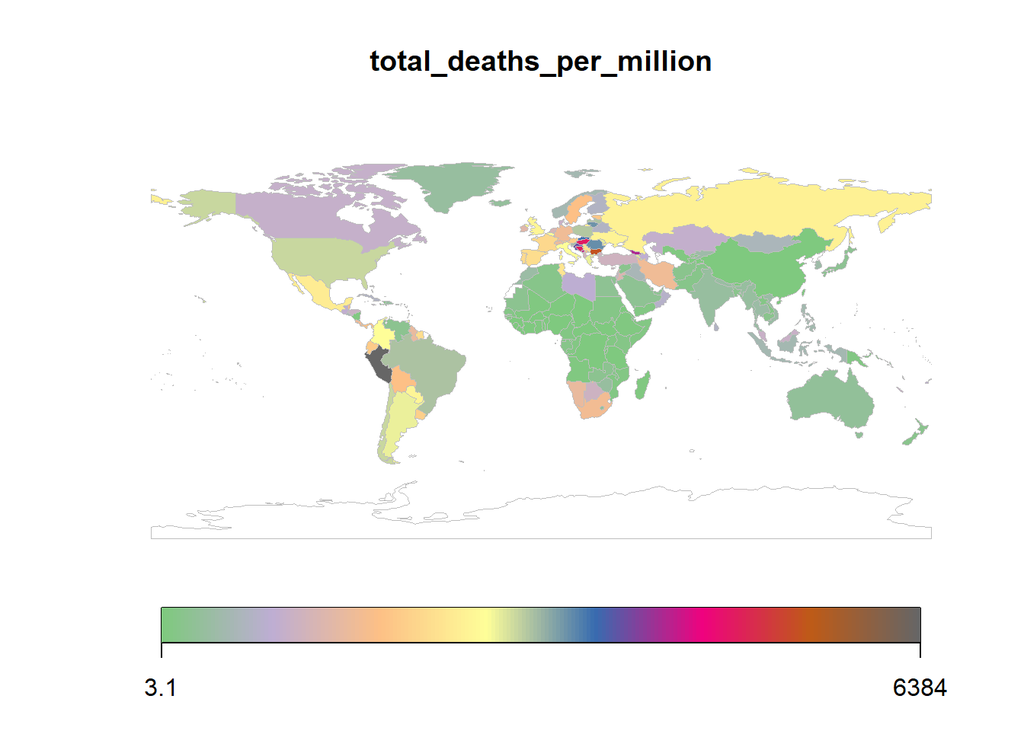

```r
colourpalette<-brewer.pal(8,'Accent')
mapCountryData(map_world_deaths,nameColumnToPlot = 'total_deaths_per_million',catMethod = 'fixedwidth',colourPalette=colourpalette,numCats = 200,missingCountryCol = "white")
```

```r
map_world_vaccinations<-joinCountryData2Map(mapdata_vaccinations,joinCode = "NAME",nameJoinColumn = "location")
```

```
## 210 codes from your data successfully matched countries in the map
## 21 codes from your data failed to match with a country code in the map
## 33 codes from the map weren't represented in your data
```

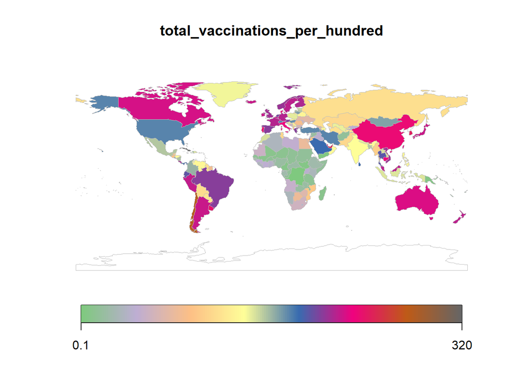

```r
mapCountryData(map_world_vaccinations,nameColumnToPlot = 'total_vaccinations_per_hundred',catMethod = 'fixedwidth',colourPalette=colourpalette,numCats = 200,missingCountryCol = "white")
```

```r
map_world_mortality<-joinCountryData2Map(mapdata_mortality,joinCode = "NAME",nameJoinColumn = "location")
```

```
## 111 codes from your data successfully matched countries in the map
## 3 codes from your data failed to match with a country code in the map
## 132 codes from the map weren't represented in your data
```

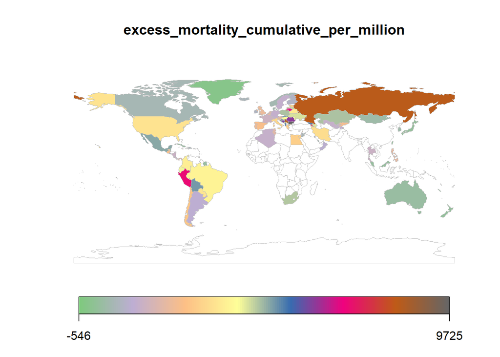

```r
mapCountryData(map_world_mortality,nameColumnToPlot = 'excess_mortality_cumulative_per_million',catMethod = 'fixedwidth',colourPalette=colourpalette,numCats = 200,missingCountryCol = "white")
```

### Question 8

In this question we choose the correlation between COVID diagnosis and death for people not surviving the disease.

###### A

```r
fun_cross_corr <- function(data_frame,name_of_country,col_1,col_2) {
data_frame<-data_frame%>% filter(location == name_of_country)
  y<-data_frame[[col_1]]
  n<-nrow(df)
  x<-data_frame[[col_2]]
  cross_vector <-rep(1:121)
  for(j in 60:0){
    cross_vector[61-j]= cor(x[1:(n-j)],y[(j+1):n],use = "complete.obs")
  }
  for(j in 1:61){
    cross_vector[60+j]= cor(y[1:(n-j)],x[(j+1):n],use = "complete.obs")
  }
  return(cross_vector)

}
```

###### B

In this sub question. we will use the function from A, and see it between new cases smoothed, and new deaths smooth for the entire world.

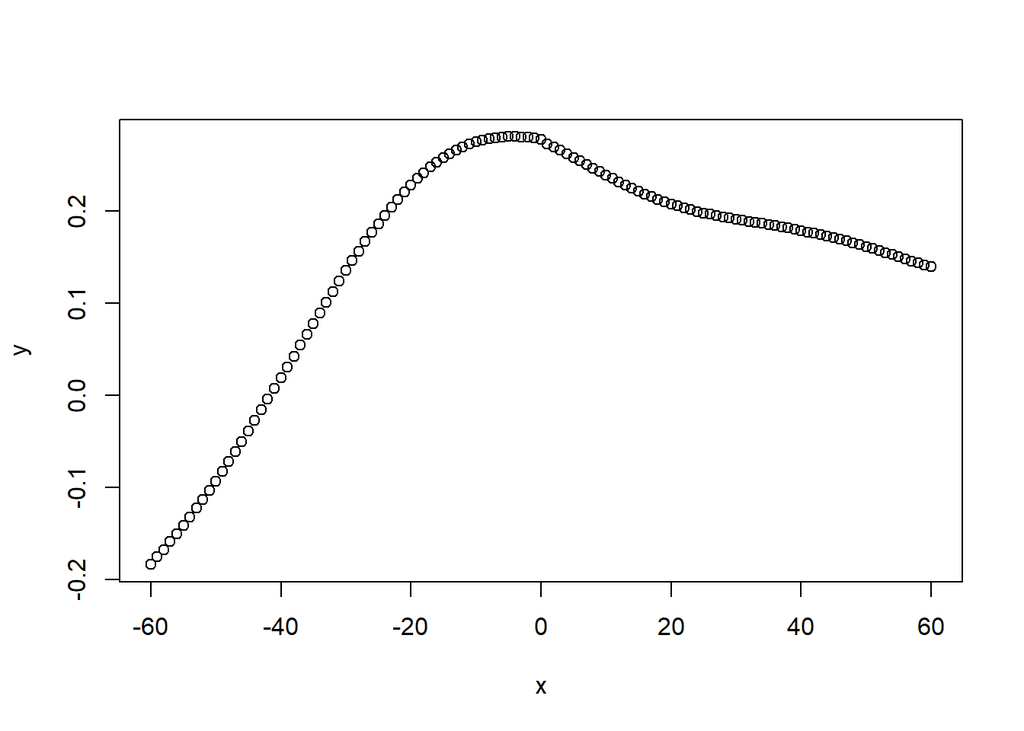

```r
x = c(60:-60)
y= fun_cross_corr(df, "World", "new_cases_smoothed", "new_deaths_smoothed")
plot(x,y)
```

##### Analysis & Results

From the graph, we can observe the critical time in the x axis is 0 and see the beginning of the decline between the two variables.

### Question 9

In this question we will compute the risk of dying from COVID-19 infection, and will plot the data based on all six continents. In sub-question B, we will make a similar plot for all the world.

###### A

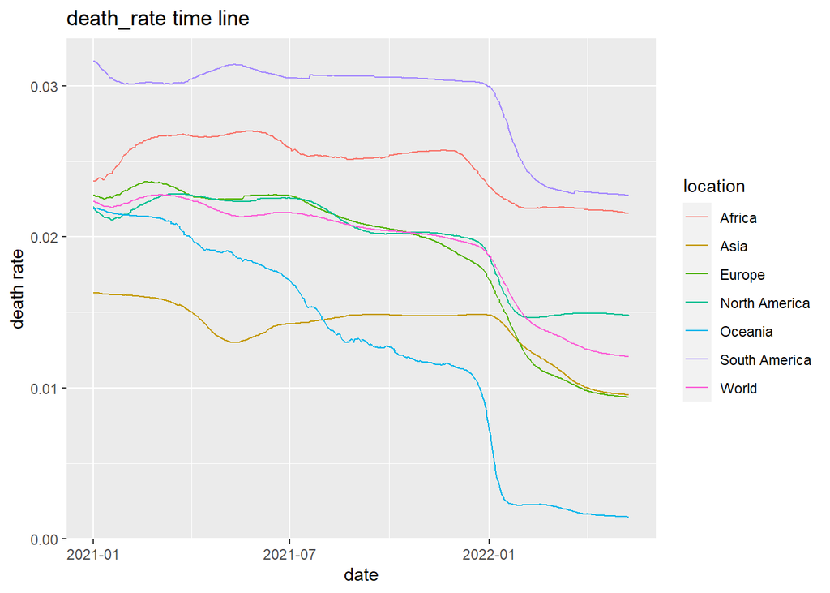

```r
df_q9 <-df %>%group_by(location)%>% mutate(death_rate = total_deaths/total_cases)
df_q9<-subset(df_q9, date >= as.Date('2021-01-01'))
df_q9 <- subset(df_q9, location %in% c('Africa', 'Asia', 'Europe', 'North America', 'Oceania', 'South America', 'World'))

# create the plots#
ggplot(df_q9, aes(x=date, y=death_rate, color=location)) + geom_line()+labs(title = 'death_rate time line',x="date", y="death rate")
```

###### B

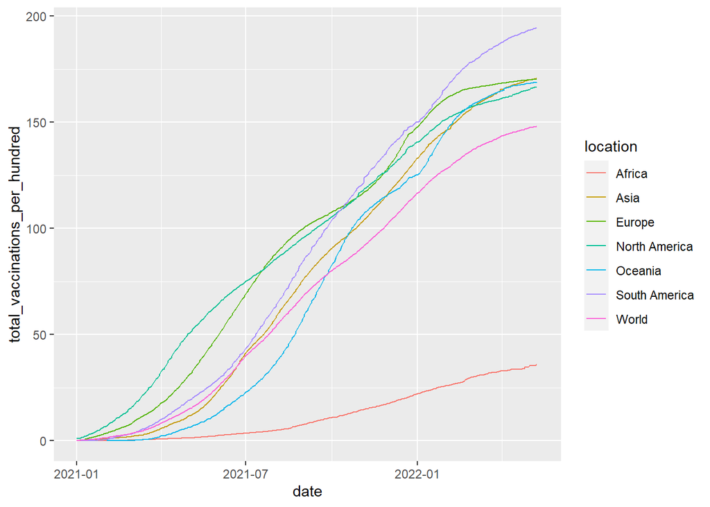

```r
ggplot(df_q9, aes(x=date, y=total_vaccinations_per_hundred, color=location)) + geom_line()
```

### Question 10

In this final question, we will try to guess the excess mortality that is been under reported in some countries. We will use the current data data frame from previous questions to make a scatter plot for total deaths per million, and the excess mortality rate per million.

###### A

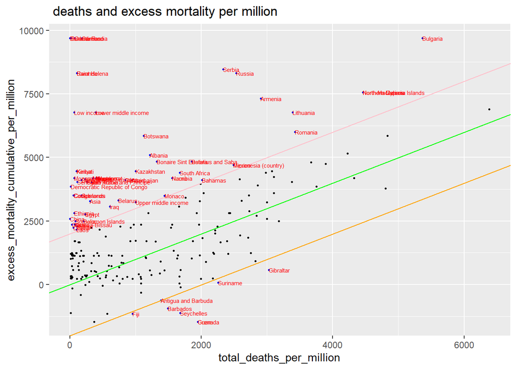

```r
current$excess_mortality = abs(current$total_deaths_per_million - current$excess_mortality_cumulative_per_million)
current_10f<-filter(current,excess_mortality>=2000)

# Now we will create the plot:
ggplot(current,aes(x= total_deaths_per_million,y=excess_mortality_cumulative_per_million))+geom_point(size = 0.5)+
  # Create the Equations mentioned in the question:
  geom_point(data =current_10f, color = "blue",size = 0.5)+geom_abline(intercept=0, slope = 1, color = "green")+geom_abline(intercept=2000, slope = 1, color = "pink")+geom_abline(intercept=-2000, slope = 1, color = "orange")+
  #Arrange the text:
  geom_text(data = current_10f,hjust= 0,nudge_x = 0.05,size =2,aes(label = location),color = "red")+  labs(title = " deaths and excess mortality per million")
```

###### B

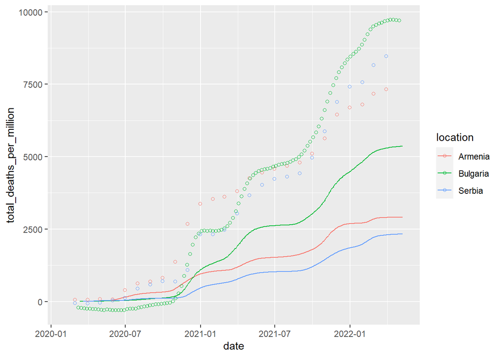

```r
#Pick three countries and create the data
chosen_countries <- c("Serbia","Armenia","Bulgaria")
df_q10 <- filter(df,location%in%chosen_countries)
df_q10 <-select(df_q10,c(location,date,total_deaths_per_million,excess_mortality_cumulative_per_million))
#create the plot
ggplot(df_q10,aes(x=date))+geom_line(aes(y = total_deaths_per_million, col = location)) +
  geom_point(aes( y = excess_mortality_cumulative_per_million, col = location), shape = 21)
```